```r
library(dplyr)
```

```r
library(ggplot2)


lags <-  read.csv(file = "timeLags_all_variables_clean.csv",sep=";")
lags <- lags %>%
  filter(!is.na(timeLag) & off_FirstRec!=0) # we keep data only with both dates and with official first record later than 2000

# Change the name of some variables for clarity

names(lags)[names(lags)=="ResearchEffort"] <- "NumAliensOff_Country"
names(lags)[names(lags)=="nOccTotSp"] <- "NumRecCS_Species"
names(lags)[names(lags)=="obsEffort_LF"] <- "NumRecCS_CountryLifeform"
```

```r
summary(lags)
```

```
##    species             Region            LifeForm          off_FirstRec
##  Length:732         Length:732         Length:732         Min.   :2010
##  Class :character   Class :character   Class :character   1st Qu.:2011
##  Mode  :character   Mode  :character   Mode  :character   Median :2013
##                                                           Mean   :2013
##                                                           3rd Qu.:2015
##                                                           Max.   :2021
##      count            firstRec       phylum             class
##  Min.   :    1.0   Min.   :1990   Length:732         Length:732
##  1st Qu.:    2.0   1st Qu.:2012   Class :character   Class :character
##  Median :    6.0   Median :2015   Mode  :character   Mode  :character
##  Mean   :  149.7   Mean   :2014
##  3rd Qu.:   25.0   3rd Qu.:2018
##  Max.   :20590.0   Max.   :2021
##     timeLag          eu_status             scopus           EASIN_Id
##  Min.   :-29.0000   Length:732         Min.   :     0.0   Length:732
##  1st Qu.:  0.0000   Class :character   1st Qu.:    20.0   Class :character
##  Median :  1.0000   Mode  :character   Median :   117.0   Mode  :character
##  Mean   :  0.8101                      Mean   :  2137.5
##  3rd Qu.:  5.0000                      3rd Qu.:   607.2
##  Max.   : 11.0000                      Max.   :255930.0
##     Status               TER              FRW               MAR
##  Length:732         Min.   :0.0000   Min.   :0.00000   Min.   :0.00000
##  Class :character   1st Qu.:1.0000   1st Qu.:0.00000   1st Qu.:0.00000
##  Mode  :character   Median :1.0000   Median :0.00000   Median :0.00000
##                     Mean   :0.9372   Mean   :0.06011   Mean   :0.04508
##                     3rd Qu.:1.0000   3rd Qu.:0.00000   3rd Qu.:0.00000
##                     Max.   :1.0000   Max.   :1.00000   Max.   :1.00000
##       OLI            habitat          worst_100_world_ISSG
##  Min.   :0.00000   Length:732         Length:732
##  1st Qu.:0.00000   Class :character   Class :character
##  Median :0.00000   Mode  :character   Mode  :character
##  Mean   :0.02049
##  3rd Qu.:0.00000
##  Max.   :1.00000
##  worst_100_Europe_DAISIE mentioned_in_EU_quarantine_species partly_native
##  Length:732              Length:732                         Length:732
##  Class :character        Class :character                   Class :character
##  Mode  :character        Mode  :character                   Mode  :character
##
```

[output cut: 8 more lines]

```
##  Max.   :10201950         Max.   :762.0        Max.   :108267.00
##  obsInNeigborCountryBefore   google_sum        google_mean
##  Mode :logical             Min.   :    0.00   Min.   : 0.000
##  FALSE:377                 1st Qu.:   21.75   1st Qu.: 0.151
##  TRUE :355                 Median :  146.00   Median : 1.014
##                            Mean   :  519.34   Mean   : 3.606
##                            3rd Qu.:  432.50   3rd Qu.: 3.003
##                            Max.   :10133.00   Max.   :70.368
##  google_country_porc google_country
##  Min.   :  0.00      Min.   :   0.0
##  1st Qu.:  0.00      1st Qu.:   0.0
##  Median :  0.00      Median :   0.0
##  Mean   : 14.05      Mean   : 134.1
##  3rd Qu.:  0.00      3rd Qu.:   0.0
##  Max.   :100.00      Max.   :5328.6
```

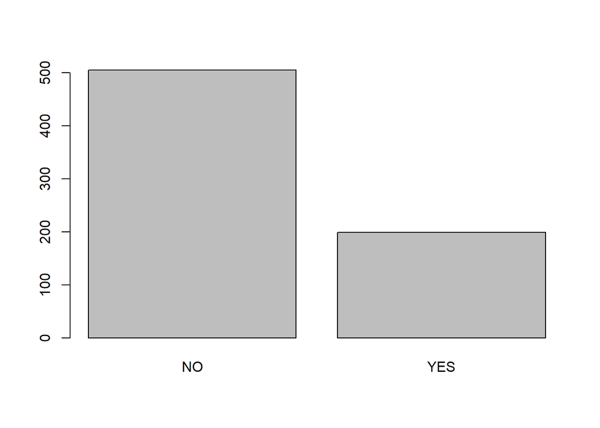

```r
barplot(table(lags$partly_native))
```

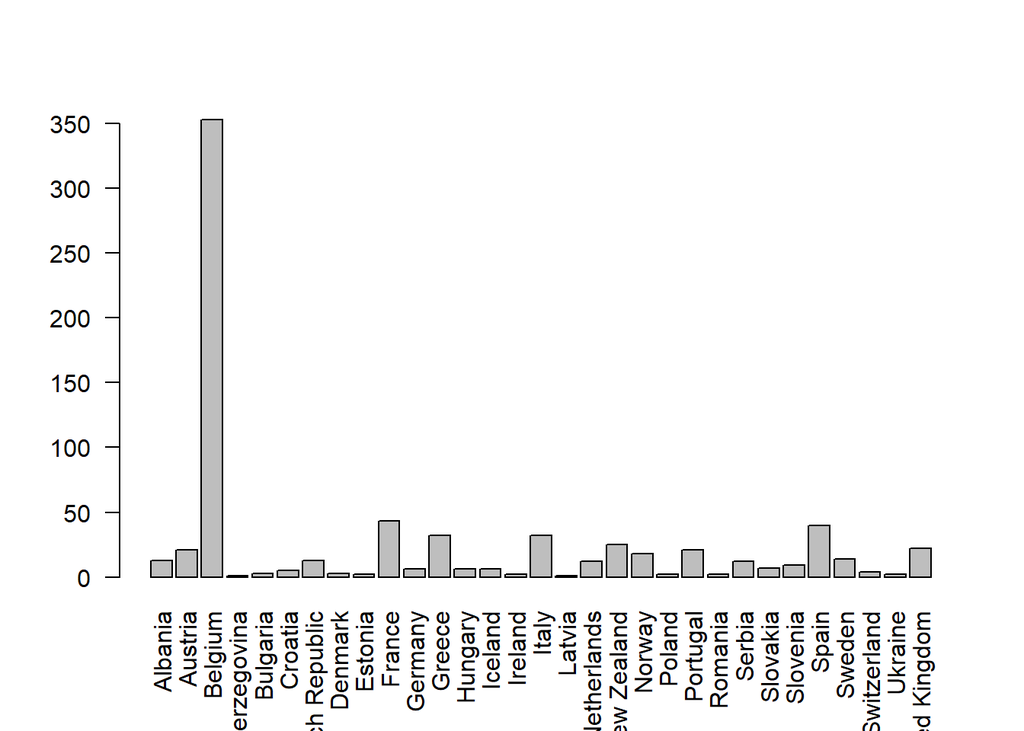

```r
barplot(table(lags$Region),las=2)
```

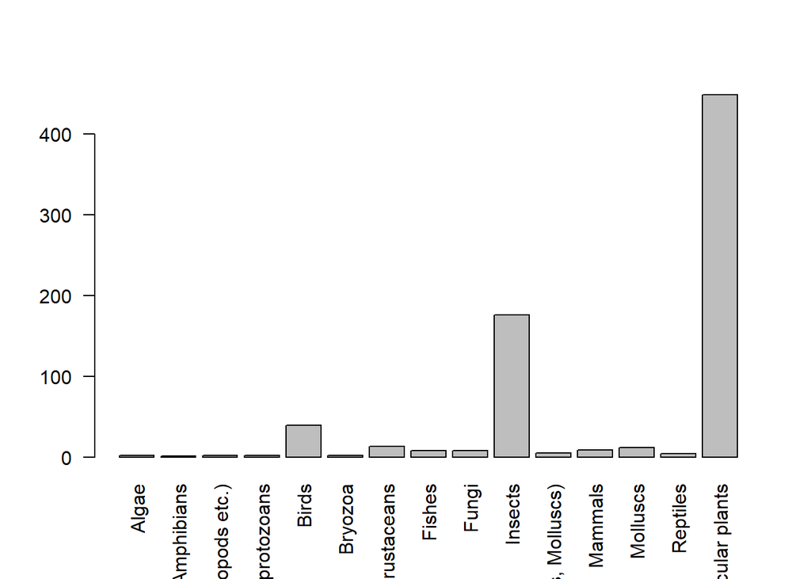

```r
barplot(table(lags$LifeForm),las=2)
```

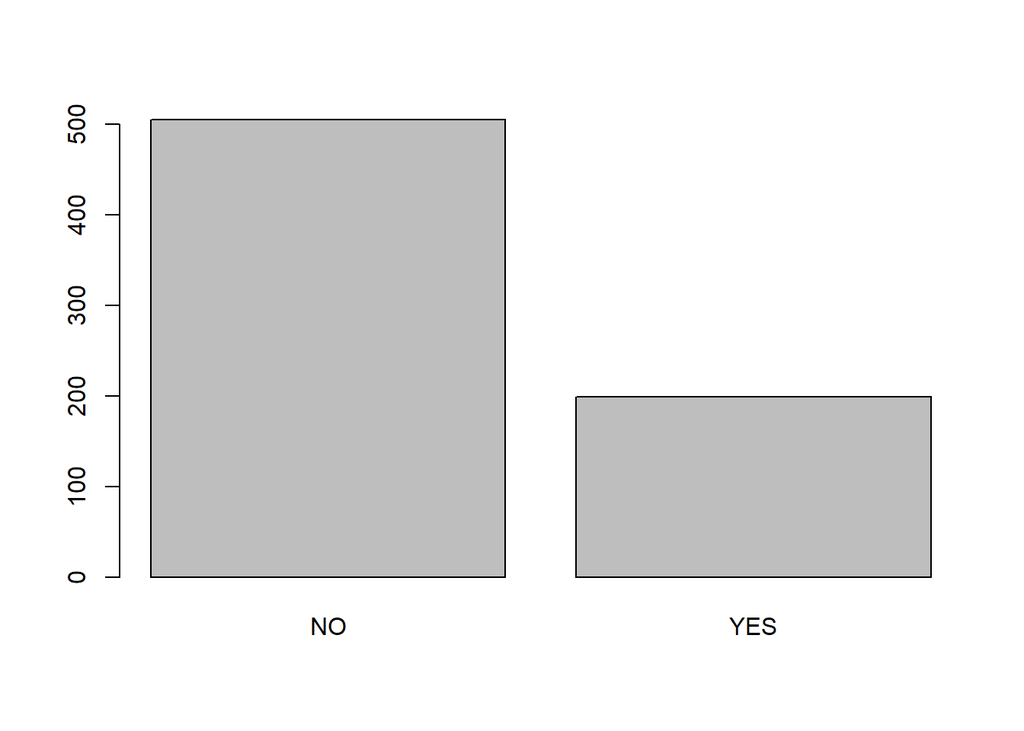

```r
barplot(table(lags$partly_native))
```

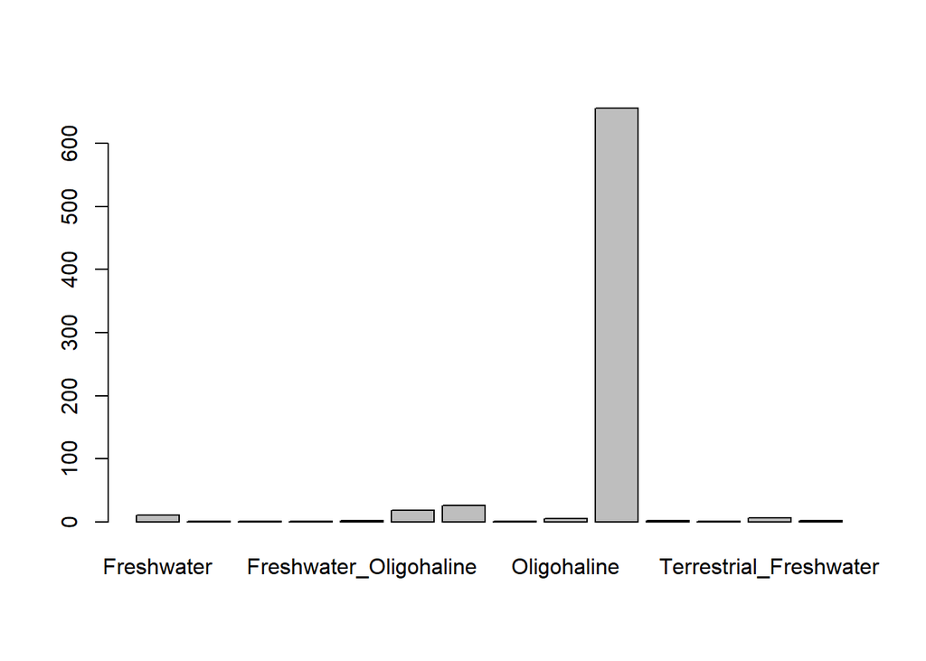

```r
barplot(table(lags$habitat))
```

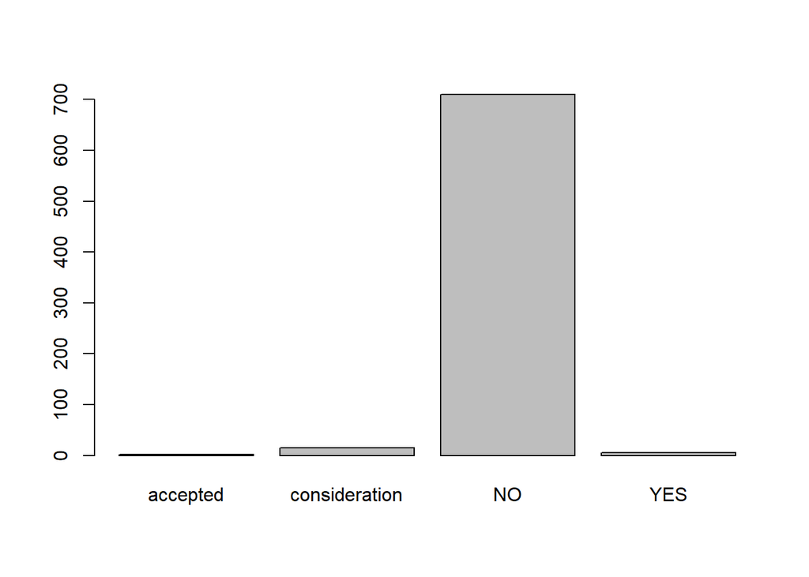

```r
barplot(table(lags$eu_status))
```

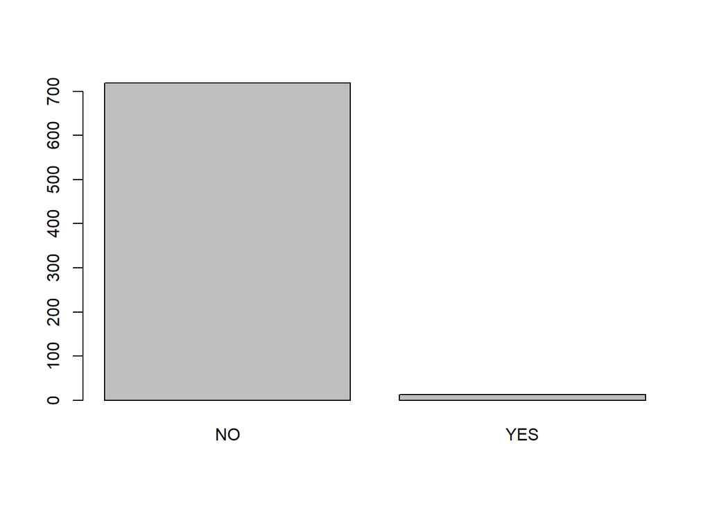

```r
barplot(table(lags$mentioned_in_EU_quarantine_species))
```

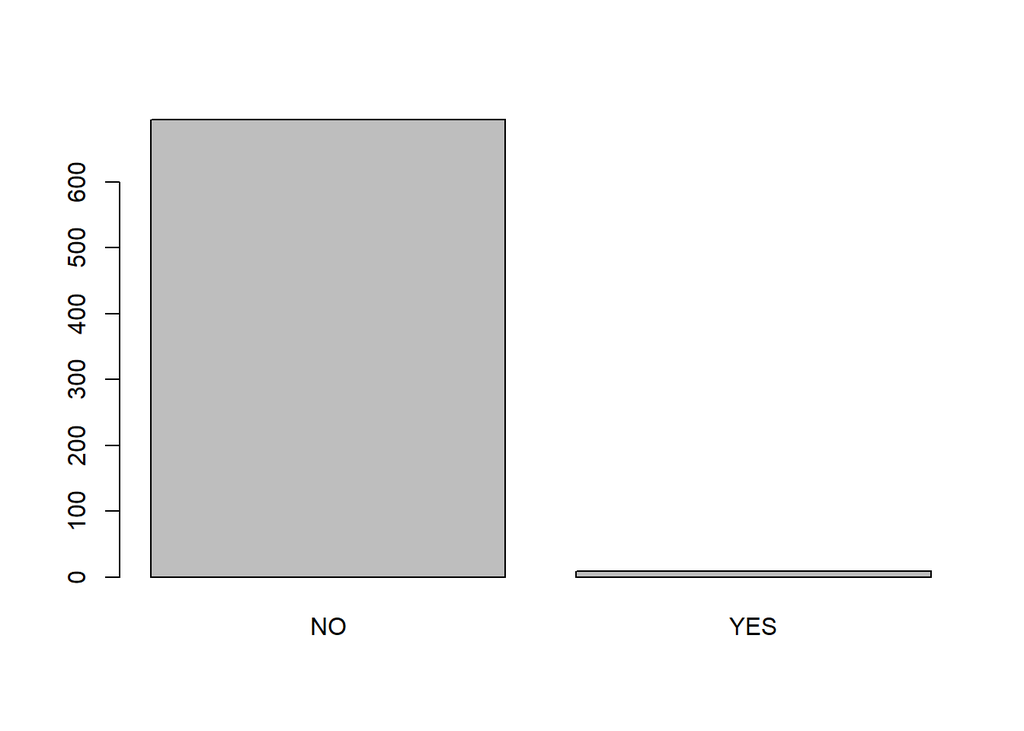

```r
barplot(table(lags$worst_100_world_ISSG))
```

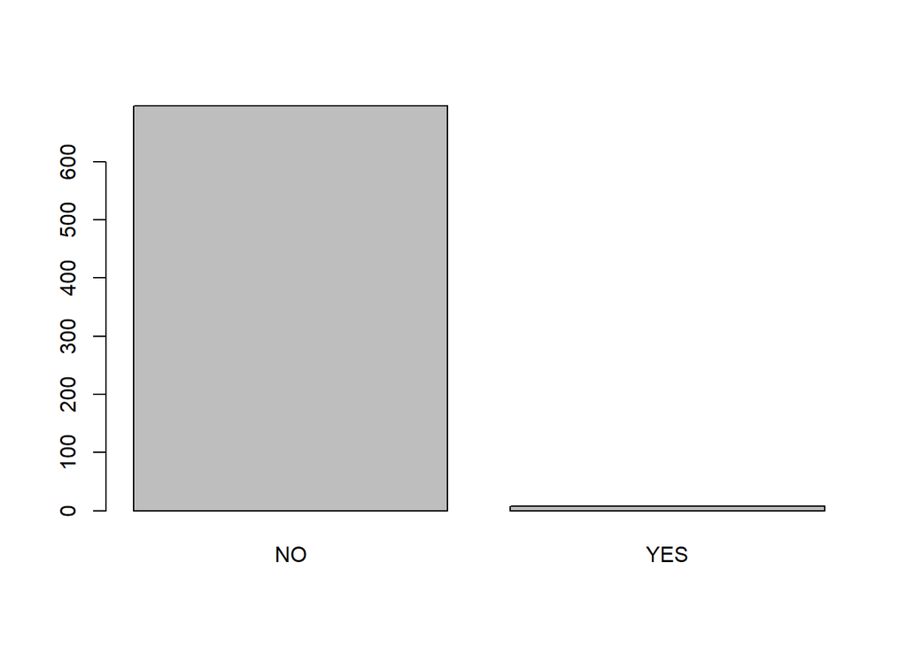

```r
barplot(table(lags$worst_100_Europe_DAISIE))
```

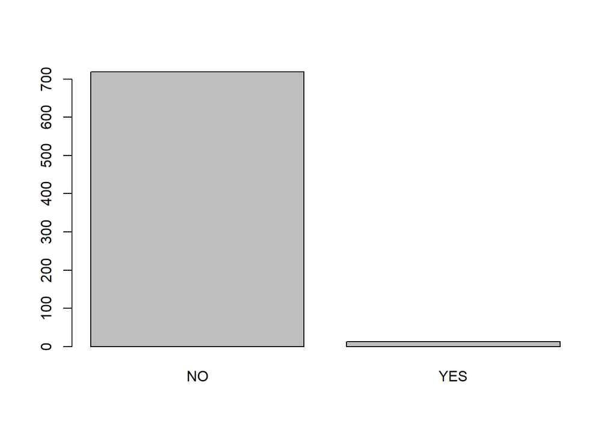

```r
barplot(table(lags$mentioned_in_EU_quarantine_species))
```

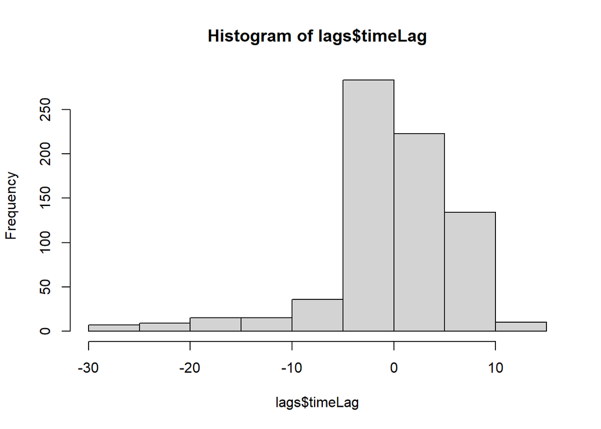

```r
# Dataset



hist(lags$timeLag)
```

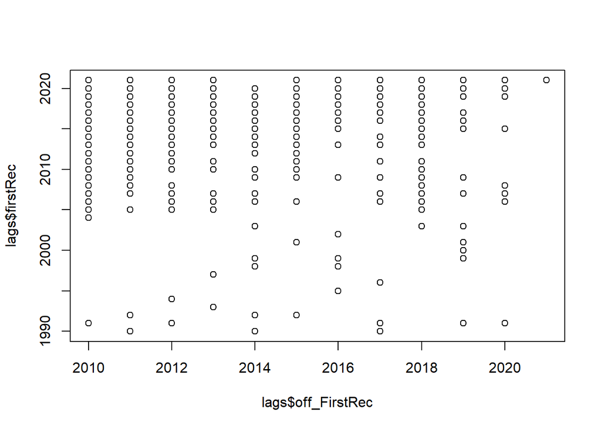

```r
plot(lags$off_FirstRec,lags$firstRec)
```

- habitat is very heterogeneous and they are mixed (one species can be marine and freshwater??). We group in two variables: (habitat2)can consider all with freshwater as aquatic. The species with a mixed of marine and other are from saline environment habitat3 separating aquatic from terrestrial
- Lifeform has many groups with extremely variable number of cases per level.
- There are 732 records with lag data. fully exotic 505
- There is a long tail towards negative lags ( citizen science very early). Now they correspond to Belgium and Sweden. - Be aware of very early citizen science dates. Up to 1990

Dataset - NumRecCS_Species (nOccTotSp) has been corrected and there aren’t gaps - Check Belgium data again (some 0 in official records)

```r
lags$Region <- as.factor(lags$Region)
lags$obsInNeigborCountryBefore <- as.factor(lags$obsInNeigborCountryBefore)

lags$habitat2 <- as.factor(lags$habitat)
summary(lags$habitat2)
```

```
##                                   Freshwater
##                                           10
## Freshwater_ Marine_ Oligohaline_ Terrestrial
##                                            1
##                      Freshwater_ Oligohaline
##                                            1
##                Freshwater_Marine_Oligohaline
##                                            1
##                       Freshwater_Oligohaline
##                                            2
##                       Freshwater_Terrestrial
##                                           18
##                                       Marine
##                                           26
##                           Marine_Oligohaline
##                                            1
##                                  Oligohaline
##                                            5
##                                  Terrestrial
##                                          656
##  Terrestrial_ Freshwater_ Marine_Oligohaline
##                                            2
##          Terrestrial_ Freshwater_Oligohaline
##                                            1
##                       Terrestrial_Freshwater
##                                            6
##    Terrestrial_Freshwater_Marine_Oligohaline
##                                            2
```

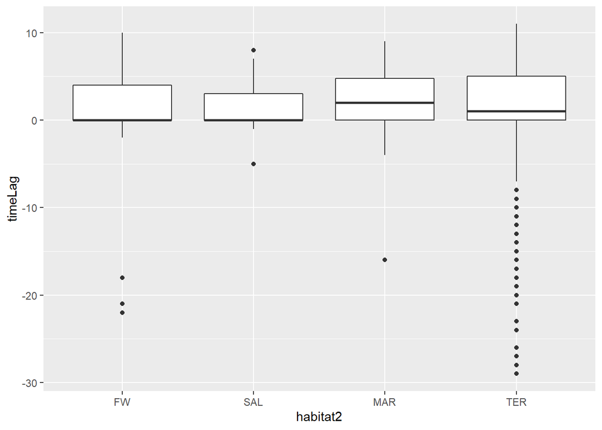

```r
levels(lags$habitat2) <- c("FW", "SAL","SAL","SAL","SAL","FW","MAR","SAL","SAL","TER","SAL","SAL","SAL","FW","SAL")
ggplot(lags,aes(y=timeLag,habitat2)) + geom_boxplot()
```

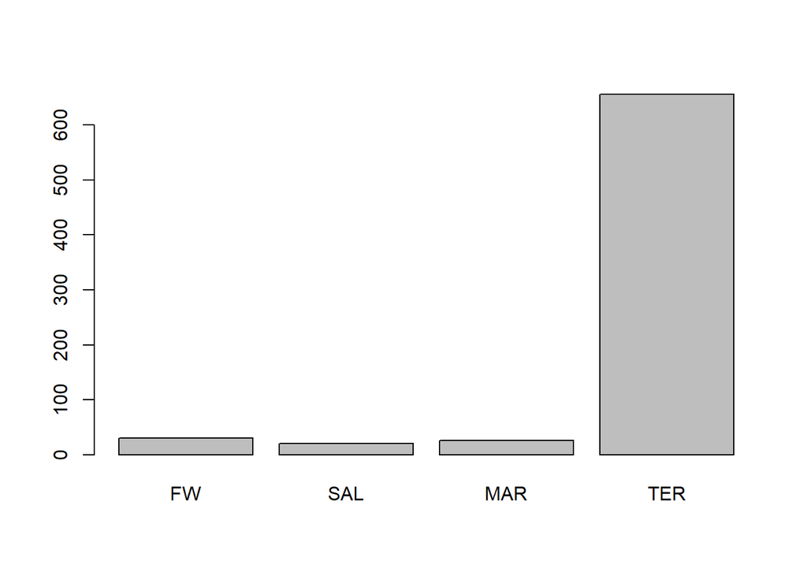

```r
barplot(table(lags$habitat2))
```

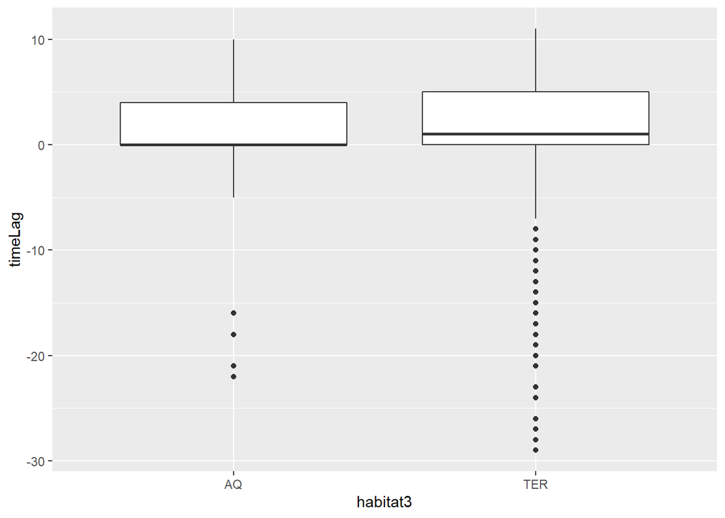

```r
lags$habitat3 <- as.factor(lags$habitat)
levels(lags$habitat3) <- c("AQ", "AQ","AQ","AQ","AQ","AQ","AQ","AQ","AQ","TER","AQ","AQ","AQ","AQ")
ggplot(lags,aes(y=timeLag,habitat3)) + geom_boxplot()
```

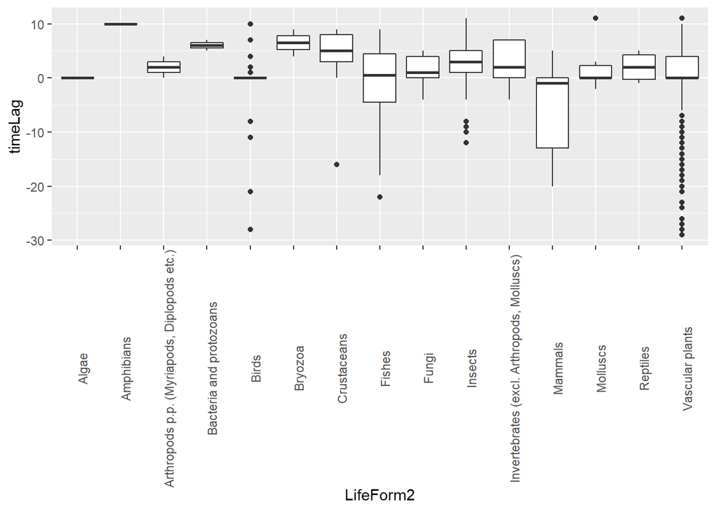

```r
lags$LifeForm2 <- as.factor(lags$LifeForm)
ggplot(lags,aes(y=timeLag,LifeForm2)) + geom_boxplot() + theme(axis.text.x = element_text(angle = 90))
```

```r
table(lags$LifeForm2)
```

```
##
##                                       Algae
##                                           2
##                                  Amphibians
##                                           1
## Arthropods p.p. (Myriapods, Diplopods etc.)
##                                           2
##                     Bacteria and protozoans
##                                           2
##                                       Birds
##                                          39
##                                     Bryozoa
##                                           2
##                                 Crustaceans
##                                          13
##                                      Fishes
##                                           8
##                                       Fungi
##                                           8
##                                     Insects
##                                         176
##  Invertebrates (excl. Arthropods, Molluscs)
##                                           5
##                                     Mammals
##                                           9
##                                    Molluscs
##                                          12
##                                    Reptiles
##                                           4
##                             Vascular plants
##                                         449
```

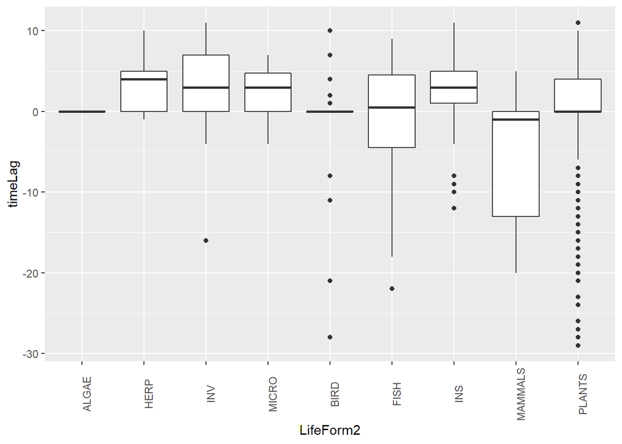

```r
levels(lags$LifeForm2) <- c("ALGAE","HERP","INV","MICRO","BIRD","INV","INV","FISH","MICRO","INS","INV","MAMMALS","INV","HERP","PLANTS")
ggplot(lags,aes(y=timeLag,LifeForm2)) + geom_boxplot() + theme(axis.text.x = element_text(angle = 90))
```

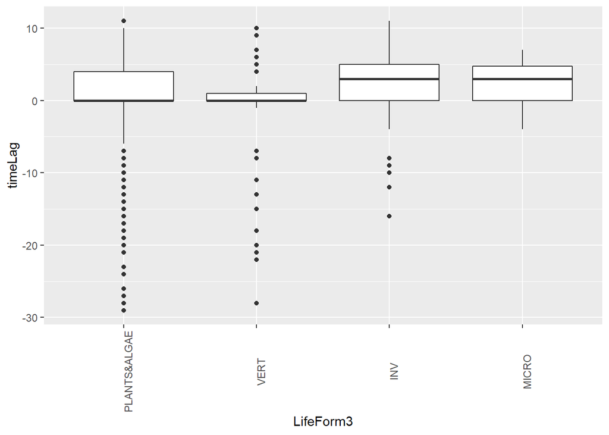

```r
lags$LifeForm3 <- as.factor(lags$LifeForm)
levels(lags$LifeForm3) <- c("PLANTS&ALGAE","VERT","INV","MICRO","VERT","INV","INV","VERT","MICRO","INV","INV","VERT","INV","VERT","PLANTS&ALGAE")
ggplot(lags,aes(y=timeLag,LifeForm3)) + geom_boxplot() + theme(axis.text.x = element_text(angle = 90))
```

```r
#create a variable indicating that at least ot is in one of the worst lists lists (ISSGS, DAISIE, EU)
lags$worst <- lags$worst_100_world_ISSG; table(lags$worst)
```

```
##
##  NO YES
## 695   9
```

```r
lags[lags$worst_100_Europe_DAISIE=="YES" &!is.na(lags$worst_100_Europe_DAISIE),"worst"] <- "YES" ; table(lags$worst)
```

```
##
##  NO YES
## 689  15
```

```r
lags[is.na(lags$worst),"worst"] <- "NO" # until we get more data we consider species without info not priority

lags$worst <- as.factor(lags$worst)


#create a variable indicating that at least ot is in one of european or quarantine satuts
lags$eu_priority <- lags$eu_status; table(lags$eu_priority)
```

```
##
##      accepted consideration            NO           YES
##             2            15           710             5
```

```r
lags[lags$eu_status!="NO","eu_priority"] <- "YES" ;

lags[is.na(lags$eu_priority),"eu_priority"] <- "NO" # until we get more data we consider species without info not priority

table(lags$eu_priority)
```

```
##
##  NO YES
## 710  22
```

```r
lags$eu_priority <- as.factor(lags$eu_priority)

# create variable for both worst and prioriy
lags$priority <- lags$eu_priority
lags[lags$worst=="YES" ,"priority"] <- "YES" ; table(lags$priority)
```

```
##
##  NO YES
## 696  36
```

```r
summary(lags)
```

```
##    species                  Region      LifeForm          off_FirstRec
##  Length:732         Belgium    :353   Length:732         Min.   :2010
##  Class :character   France     : 43   Class :character   1st Qu.:2011
##  Mode  :character   Spain      : 40   Mode  :character   Median :2013
##                     Greece     : 32                      Mean   :2013
##                     Italy      : 32                      3rd Qu.:2015
##                     New Zealand: 25                      Max.   :2021
##                     (Other)    :207
##      count            firstRec       phylum             class
##  Min.   :    1.0   Min.   :1990   Length:732         Length:732
##  1st Qu.:    2.0   1st Qu.:2012   Class :character   Class :character
##  Median :    6.0   Median :2015   Mode  :character   Mode  :character
##  Mean   :  149.7   Mean   :2014
##  3rd Qu.:   25.0   3rd Qu.:2018
##  Max.   :20590.0   Max.   :2021
##
##     timeLag          eu_status             scopus           EASIN_Id
##  Min.   :-29.0000   Length:732         Min.   :     0.0   Length:732
##  1st Qu.:  0.0000   Class :character   1st Qu.:    20.0   Class :character
##  Median :  1.0000   Mode  :character   Median :   117.0   Mode  :character
##  Mean   :  0.8101                      Mean   :  2137.5
##  3rd Qu.:  5.0000                      3rd Qu.:   607.2
##  Max.   : 11.0000                      Max.   :255930.0
##
##     Status               TER              FRW               MAR
##  Length:732         Min.   :0.0000   Min.   :0.00000   Min.   :0.00000
##  Class :character   1st Qu.:1.0000   1st Qu.:0.00000   1st Qu.:0.00000
##  Mode  :character   Median :1.0000   Median :0.00000   Median :0.00000
##                     Mean   :0.9372   Mean   :0.06011   Mean   :0.04508
##                     3rd Qu.:1.0000   3rd Qu.:0.00000   3rd Qu.:0.00000
##                     Max.   :1.0000   Max.   :1.00000   Max.   :1.00000
##
##       OLI            habitat          worst_100_world_ISSG
##  Min.   :0.00000   Length:732         Length:732
##  1st Qu.:0.00000   Class :character   Class :character
##  Median :0.00000   Mode  :character   Mode  :character
##  Mean   :0.02049
##  3rd Qu.:0.00000
##  Max.   :1.00000
##
```

[output cut: 25 more lines]

```
##  Min.   :  0.00      Min.   :   0.0   FW : 30   AQ : 76   PLANTS :449
##  1st Qu.:  0.00      1st Qu.:   0.0   SAL: 20   TER:656   INS    :176
##  Median :  0.00      Median :   0.0   MAR: 26             BIRD   : 39
##  Mean   : 14.05      Mean   : 134.1   TER:656             INV    : 34
##  3rd Qu.:  0.00      3rd Qu.:   0.0                       MICRO  : 10
##  Max.   :100.00      Max.   :5328.6                       MAMMALS:  9
##                                                           (Other): 15
##         LifeForm3   worst     eu_priority priority
##  PLANTS&ALGAE:451   NO :717   NO :710     NO :696
##  VERT        : 61   YES: 15   YES: 22     YES: 36
##  INV         :210
##  MICRO       : 10
##
##
##
```

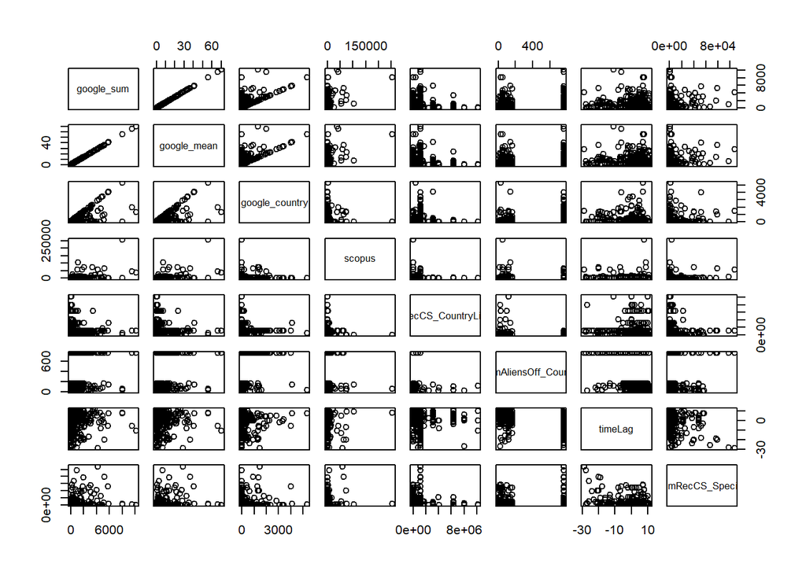

```r
variables <- c("habitat2","habitat3", "LifeForm2","LifeForm3","Region","priority","eu_priority","worst","obsInNeigborCountryBefore", "google_sum","google_mean","google_country","scopus","NumRecCS_CountryLifeform","NumAliensOff_Country","timeLag","NumRecCS_Species")

plot(lags[,variables[10:17]])
```

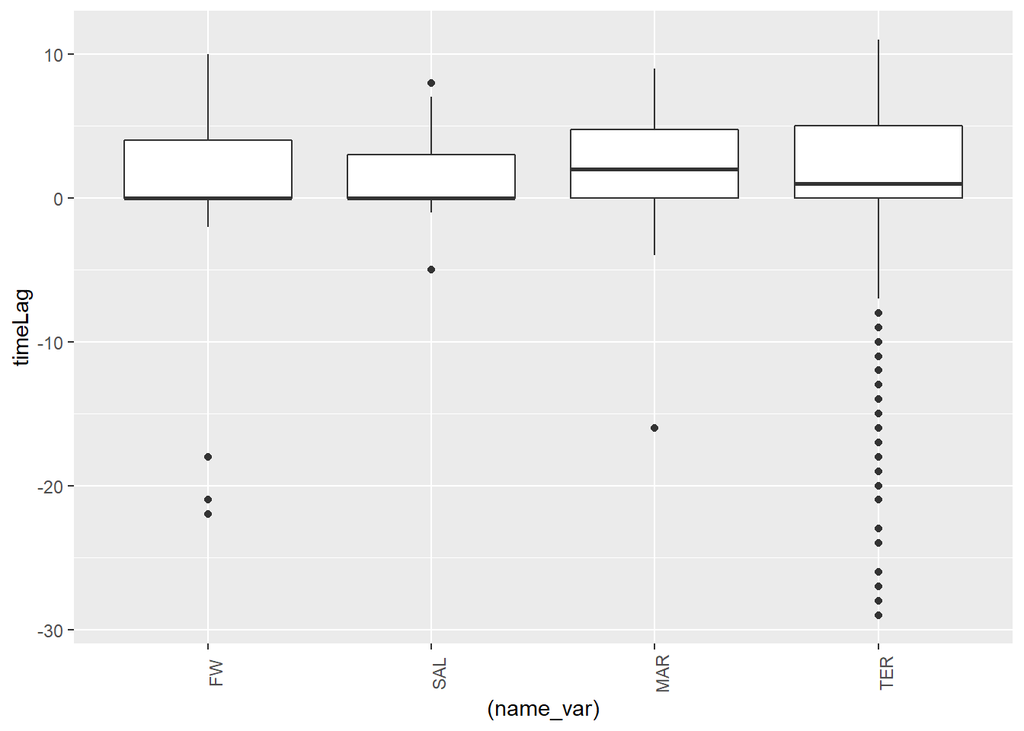

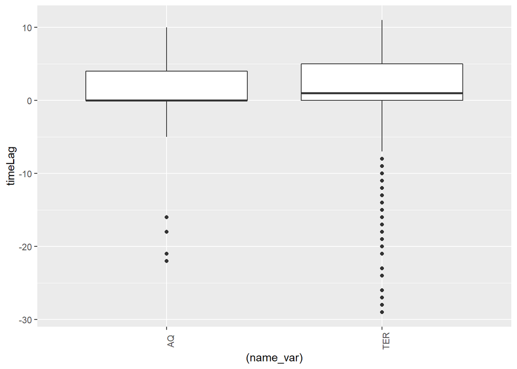

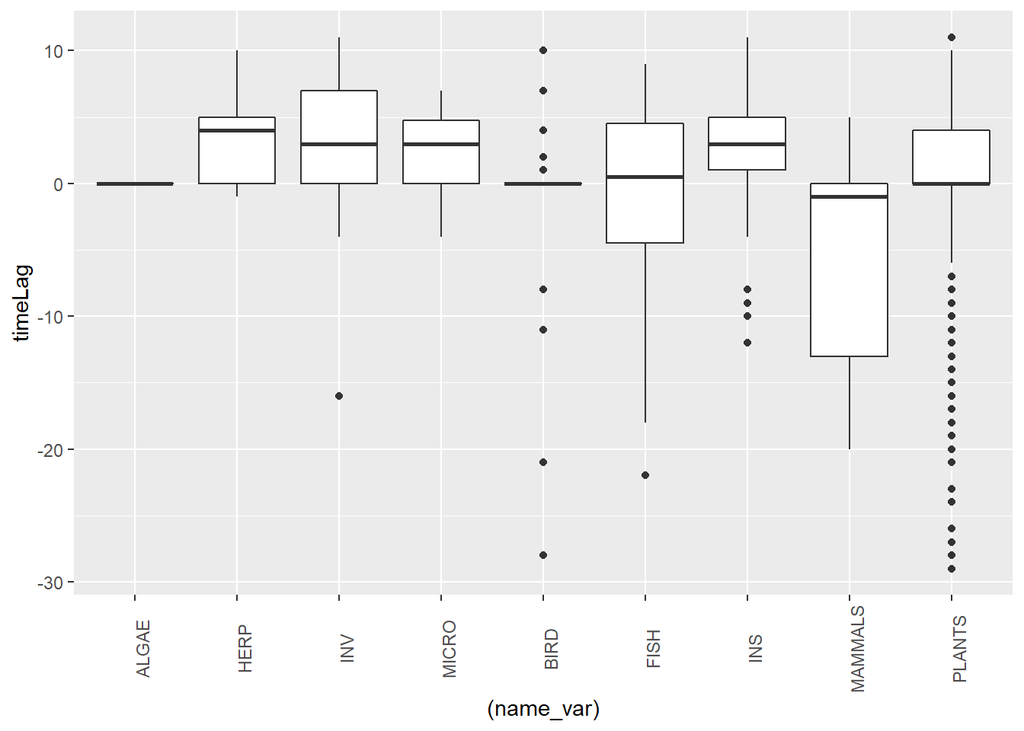

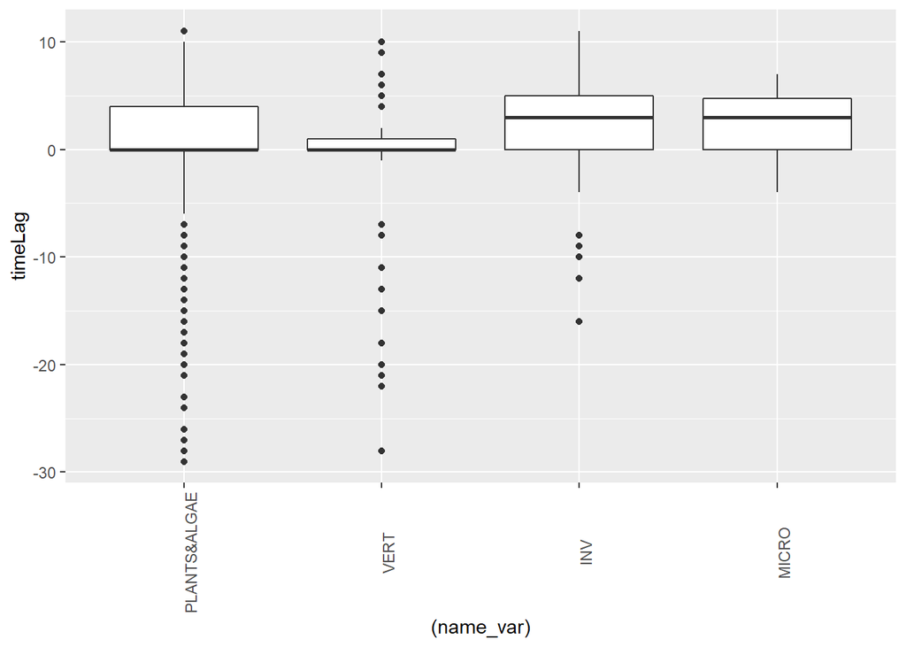

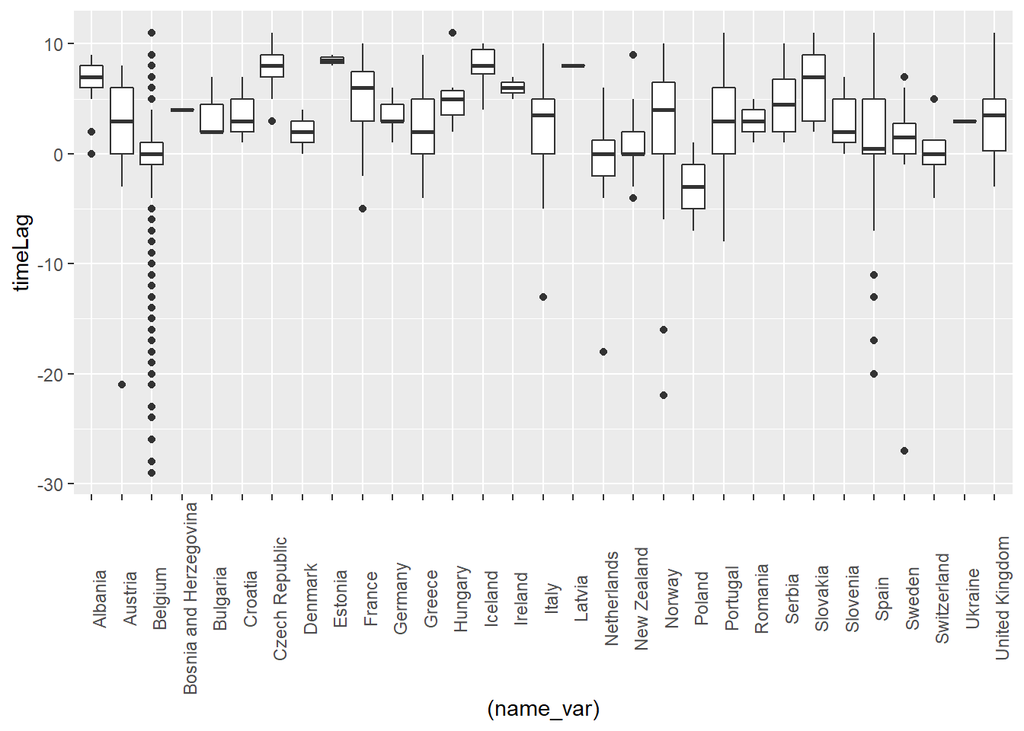

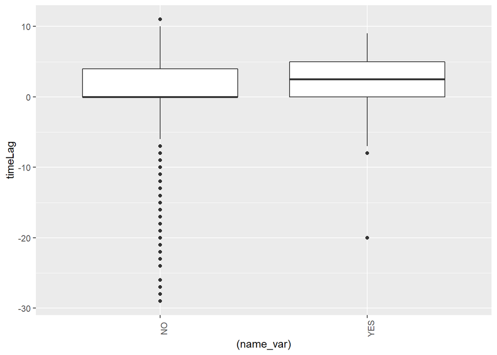

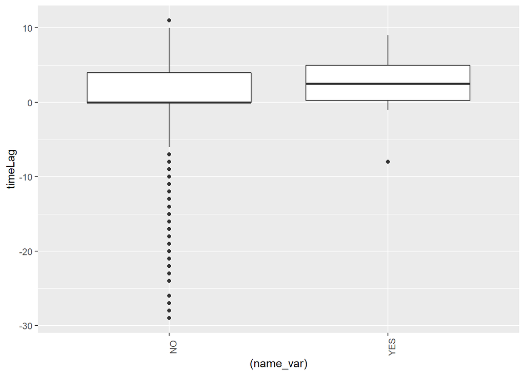

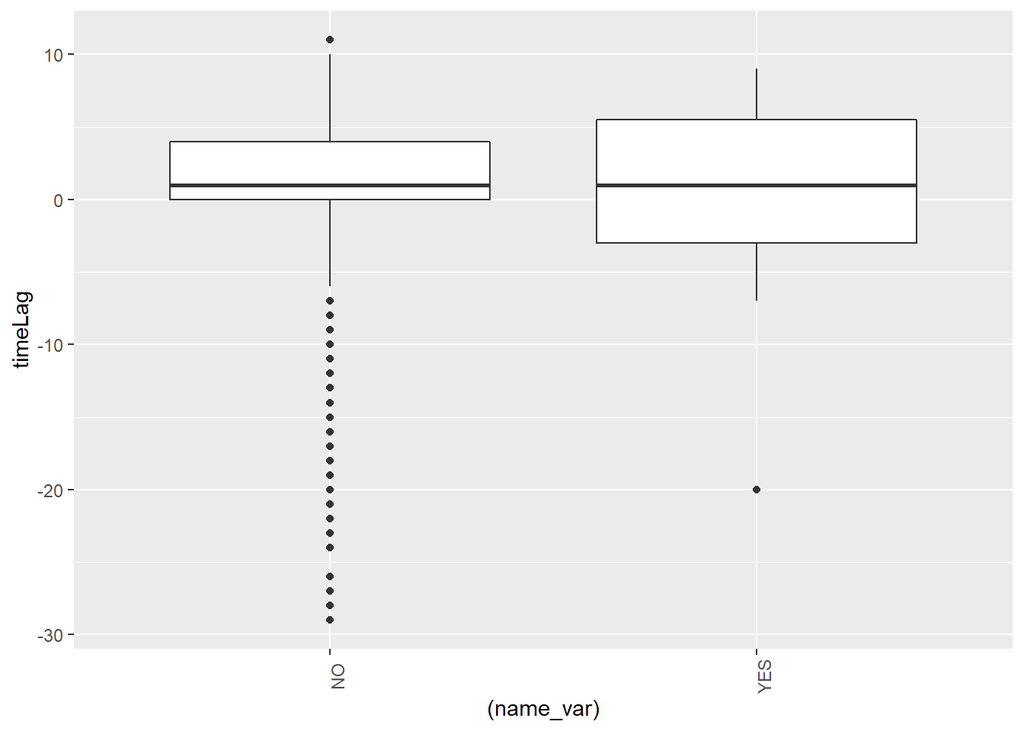

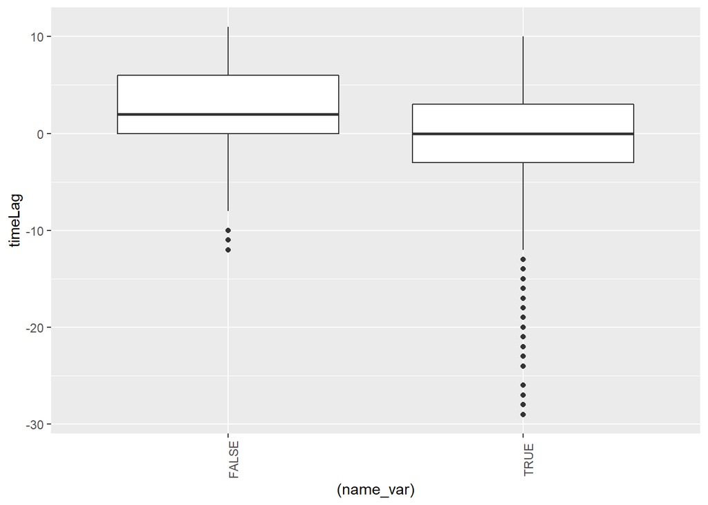

```r
for(i in 1:9) {
    name_var <- lags[,variables[i]]
    p<- ggplot(lags,aes(y=timeLag,x=(name_var))) + geom_boxplot() + theme(axis.text.x = element_text(angle = 90))
    print(p)
}
```

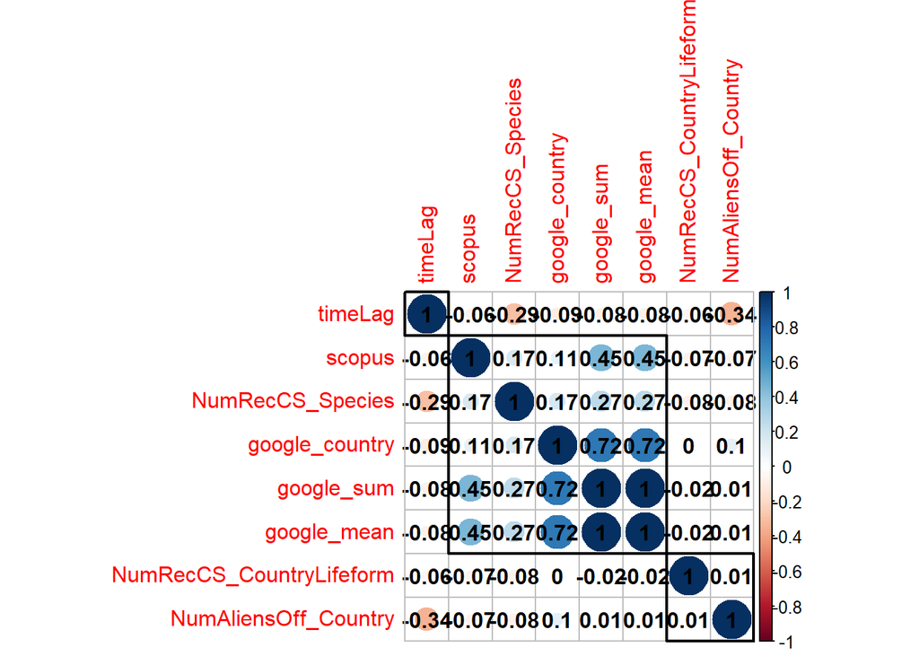

```r
library(corrplot)
cormat <- cor(lags[,variables[10:17]])

corrplot(cormat,order = 'hclust',addrect = 3,addCoef.col = "black")
```

```r
library(lsr)
str(lags[,variables[1:9]])
```

```
## 'data.frame':    732 obs. of  9 variables:
##  $ habitat2                 : Factor w/ 4 levels "FW","SAL","MAR",..: 4 4 4 4 4 4 4 4 4 4 ...
##  $ habitat3                 : Factor w/ 2 levels "AQ","TER": 2 2 2 2 2 2 2 2 2 2 ...
##  $ LifeForm2                : Factor w/ 9 levels "ALGAE","HERP",..: 9 9 9 9 9 9 9 9 9 9 ...
##  $ LifeForm3                : Factor w/ 4 levels "PLANTS&ALGAE",..: 1 1 1 1 1 1 1 1 1 1 ...
##  $ Region                   : Factor w/ 31 levels "Albania","Austria",..: 3 3 3 20 10 3 3 3 3 1 ...
##  $ priority                 : Factor w/ 2 levels "NO","YES": 1 1 1 1 1 1 1 1 1 1 ...
##  $ eu_priority              : Factor w/ 2 levels "NO","YES": 1 1 1 1 1 1 1 1 1 1 ...
##  $ worst                    : Factor w/ 2 levels "NO","YES": 1 1 1 1 1 1 1 1 1 1 ...
##  $ obsInNeigborCountryBefore: Factor w/ 2 levels "FALSE","TRUE": 2 2 2 2 1 1 2 1 2 2 ...
```

```r
cramersV(table(lags[,c("habitat2","LifeForm2")]))
```

```
## [1] 0.5806446
```

```r
cramersV(table(lags[,c("habitat3","LifeForm3")]))
```

```
## [1] 0.2776168
```

```r
cramersV(table(lags[,c("habitat2","LifeForm3")]))
```

```
## [1] 0.2302301
```

```r
cramersV(table(lags[,c("habitat3","LifeForm2")]))
```

```
## [1] 0.7606774
```

```r
# Scale variables to improve convergence
lags[,variables[c(10:15,17)]] <- scale(lags[,variables[c(10:15,17)]])
```

There isn’t large correlation among continuous variables apart from google data - Google_sum and google_mean are the same - We can use the google_country or google_mean but not both together - Least association between habitat and lifeform is using habitat2 and lifeform3

# Model with all variables

```r
# lme4
library(lme4)
library(multcomp)
library(lmerTest)
library(MuMIn);options(na.action = "na.fail")

modelbas <- lmer(timeLag~  google_country+ scopus + NumAliensOff_Country +habitat2+ LifeForm3 + obsInNeigborCountryBefore+NumRecCS_Species+NumRecCS_CountryLifeform + eu_priority+worst+(1|Region),data=lags )
summary(modelbas)
```

```
## Linear mixed model fit by REML. t-tests use Satterthwaite's method [
## lmerModLmerTest]
## Formula: timeLag ~ google_country + scopus + NumAliensOff_Country + habitat2 +
##     LifeForm3 + obsInNeigborCountryBefore + NumRecCS_Species +
##     NumRecCS_CountryLifeform + eu_priority + worst + (1 | Region)
##    Data: lags
##
## REML criterion at convergence: 4424.5
##
## Scaled residuals:
##     Min      1Q  Median      3Q     Max
## -4.8041 -0.3694  0.0562  0.5974  2.6216
##
## Random effects:
##  Groups   Name        Variance Std.Dev.
##  Region   (Intercept)  8.335   2.887
##  Residual             24.072   4.906
## Number of obs: 732, groups:  Region, 31
##
## Fixed effects:
##                                Estimate Std. Error        df t value Pr(>|t|)
## (Intercept)                     2.27132    1.73125  29.14269   1.312  0.19977
## google_country                  0.08652    0.19152 702.53990   0.452  0.65157
## scopus                         -0.26799    0.20258 715.69581  -1.323  0.18630
## NumAliensOff_Country           -2.48252    1.38482  15.26298  -1.793  0.09287
## habitat2SAL                     1.15713    1.47642 716.35905   0.784  0.43345
## habitat2MAR                    -2.35726    1.46343 715.73276  -1.611  0.10767
## habitat2TER                     0.22856    0.96817 699.73971   0.236  0.81344
## LifeForm3VERT                  -2.30189    0.72967 704.36377  -3.155  0.00167
## LifeForm3INV                    0.19486    0.59405 709.16338   0.328  0.74300
## LifeForm3MICRO                 -0.18068    1.76037 652.72006  -0.103  0.91828
## obsInNeigborCountryBeforeTRUE  -3.29351    0.39858 714.63745  -8.263 6.89e-16
## NumRecCS_Species               -2.53643    0.21665 716.84622 -11.708  < 2e-16
## NumRecCS_CountryLifeform       -0.24120    0.24362 533.41240  -0.990  0.32259
## eu_priorityYES                  6.21292    1.21643 712.52143   5.108 4.20e-07
## worstYES                        1.19265    1.37677 710.82231   0.866  0.38664
##
## (Intercept)
## google_country
## scopus
## NumAliensOff_Country          .
## habitat2SAL
## habitat2MAR
## habitat2TER
## LifeForm3VERT                 **
## LifeForm3INV
## LifeForm3MICRO
## obsInNeigborCountryBeforeTRUE ***
## NumRecCS_Species              ***
## NumRecCS_CountryLifeform
## eu_priorityYES                ***
## worstYES
## ---
## Signif. codes:  0 '***' 0.001 '**' 0.01 '*' 0.05 '.' 0.1 ' ' 1
```

```
##
## Correlation matrix not shown by default, as p = 15 > 12.
## Use print(x, correlation=TRUE)  or
##     vcov(x)        if you need it
```

```r
comp <- dredge(modelbas)
```

```
## Fixed term is "(Intercept)"
```

```r
comp
```

```
## Global model call: lmer(formula = timeLag ~ google_country + scopus + NumAliensOff_Country +
##     habitat2 + LifeForm3 + obsInNeigborCountryBefore + NumRecCS_Species +
##     NumRecCS_CountryLifeform + eu_priority + worst + (1 | Region),
##     data = lags)
## ---
## Model selection table
##         (Int) eu_prr    ggl_cnt hb2 LF3 NAO_Cnt  NRC_CnL NRC_Spc oIN     scp
## 734   2.25700      +              +   +  -2.451           -2.551   +
## 222   2.32700      +              +   +  -2.458           -2.543   +
## 990   2.28500      +              +   +  -2.476           -2.517   + -0.2515
## 766   2.22900      +              +   +  -2.445 -0.22990  -2.554   +
## 254   2.29000      +              +   +  -2.452 -0.24060  -2.547   +
## 478   2.37500      +              +   +  -2.483           -2.511   + -0.2097
## 718   4.55000      +              +   +                   -2.544   +
## 736   2.26700      +  0.0642500   +   +  -2.458           -2.565   +
```

[output cut: 2044 more lines]

```r
summary(model.avg(comp,subset = delta < 4))
```

```
##
## Call:
## model.avg(object = comp, subset = delta < 4)
##
## Component model call:
## lmer(formula = timeLag ~ <8 unique rhs>, data = lags)
##
## Component models:
##                  df   logLik    AICc delta weight
## 1+3+4+5+7+8+10   14 -2211.68 4451.94  0.00   0.31
## 1+3+4+5+7+8      13 -2213.11 4452.73  0.79   0.21
## 1+3+4+5+7+8+9+10 15 -2211.59 4453.84  1.90   0.12
## 1+3+4+5+6+7+8+10 15 -2211.75 4454.16  2.22   0.10
## 1+3+4+5+6+7+8    14 -2213.14 4454.86  2.92   0.07
## 1+3+4+5+7+8+9    14 -2213.25 4455.09  3.15   0.06
## 1+3+4+7+8+10     13 -2214.42 4455.35  3.41   0.06
## 1+2+3+4+5+7+8+10 15 -2212.36 4455.39  3.45   0.06
##
## Term codes:
##               eu_priority            google_country                  habitat2
##                         1                         2                         3
##                 LifeForm3      NumAliensOff_Country  NumRecCS_CountryLifeform
##                         4                         5                         6
##          NumRecCS_Species obsInNeigborCountryBefore                    scopus
##                         7                         8                         9
##                     worst
##                        10
##
## Model-averaged coefficients:
## (full average)
##                                Estimate Std. Error Adjusted SE z value Pr(>|z|)
## (Intercept)                    2.413556   1.793887    1.796655   1.343 0.179155
## eu_priorityYES                 6.310231   1.212657    1.214702   5.195    2e-07
## habitat2SAL                    1.367894   1.467576    1.470050   0.931 0.352108
## habitat2MAR                   -2.114555   1.443010    1.445434   1.463 0.143489
## habitat2TER                    0.172709   0.963148    0.964770   0.179 0.857925
## LifeForm3VERT                 -2.411236   0.723801    0.725020   3.326 0.000882
## LifeForm3INV                   0.295716   0.587894    0.588879   0.502 0.615549
## LifeForm3MICRO                 0.081584   1.747994    1.750928   0.047 0.962836
## NumAliensOff_Country          -2.317607   1.472777    1.474892   1.571 0.116096
```

[output cut: 43 more lines]

```
## habitat2SAL
## habitat2MAR
## habitat2TER
## LifeForm3VERT                 ***
## LifeForm3INV
## LifeForm3MICRO
## NumAliensOff_Country          .
## NumRecCS_Species              ***
## obsInNeigborCountryBeforeTRUE ***
## worstYES
## scopus
## NumRecCS_CountryLifeform
## google_country
## ---
## Signif. codes:  0 '***' 0.001 '**' 0.01 '*' 0.05 '.' 0.1 ' ' 1
```

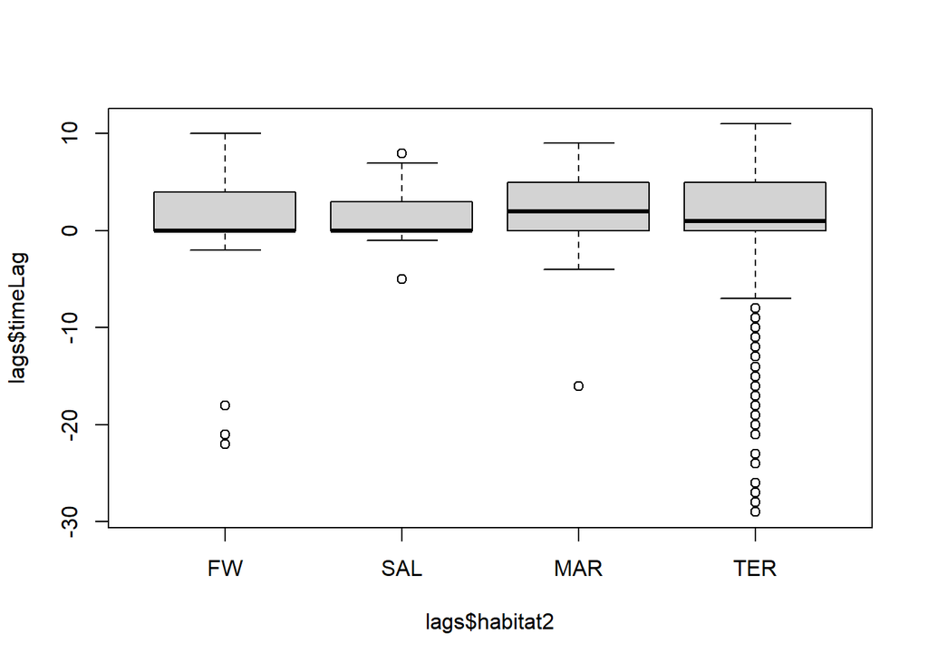

```r
boxplot(lags$timeLag~lags$habitat2)
```